## B.2 배열(arrays)과 행렬(matrices)

> 배열 또는 행렬을 생성하는 가장 기본적인 방법은 벡터를 변형하는 것이다.  
> 즉, 데이터를 일단 벡터 형태로 읽어서 배열 혹은 행렬 형태로 모양을 바꾼다.  
> `array()` 함수, `matrix()` 함수를 이용해 생성한다.

```r
    z <- array(1:20, dim=c(4,5))     # 벡터 1:20를 4*5 배열로 재배치
    z
```

```
##      [,1] [,2] [,3] [,4] [,5]
## [1,]    1    5    9   13   17
## [2,]    2    6   10   14   18
## [3,]    3    7   11   15   19
## [4,]    4    8   12   16   20
```

```r
    z <- matrix(1:20, 4, 5)
    z
```

```
##      [,1] [,2] [,3] [,4] [,5]
## [1,]    1    5    9   13   17
## [2,]    2    6   10   14   18
## [3,]    3    7   11   15   19
## [4,]    4    8   12   16   20
```

```r
    z <- matrix(2, 4, 5)
    z
```

```
##      [,1] [,2] [,3] [,4] [,5]
## [1,]    2    2    2    2    2
## [2,]    2    2    2    2    2
## [3,]    2    2    2    2    2
## [4,]    2    2    2    2    2
```

```r
    z <- matrix(c(1, 2, 3,
                  4, 5, 6),
                nrow = 2, ncol = 3, byrow=T)  # Readability enhanced
    z
```

```
##      [,1] [,2] [,3]
## [1,]    1    2    3
## [2,]    4    5    6
```

```r
    z[2, 3]                     # indexed by the position
```

```
## [1] 6
```

> 기존의 벡터(들) 또는 행렬(들)을 결합해 새로운 행렬을 만들 수 있다.

```r
    x <- 1:4
    y <- 5:8

    cbind(x, y)
```

```
##      x y
## [1,] 1 5
## [2,] 2 6
## [3,] 3 7
## [4,] 4 8
```

```r
    rbind(x, y)
```

```
##   [,1] [,2] [,3] [,4]
## x    1    2    3    4
## y    5    6    7    8
```

```r
    B <- matrix(0, 4, 5)
    cbind(B, 1:4)
```

```
##      [,1] [,2] [,3] [,4] [,5] [,6]
## [1,]    0    0    0    0    0    1
## [2,]    0    0    0    0    0    2
## [3,]    0    0    0    0    0    3
## [4,]    0    0    0    0    0    4
```

```r
    A <- matrix(1:20, 4, 5)
    B <- matrix(1:20, 4, 5)
    C <- cbind(A, B)
    C
```

```
##      [,1] [,2] [,3] [,4] [,5] [,6] [,7] [,8] [,9] [,10]
## [1,]    1    5    9   13   17    1    5    9   13    17
## [2,]    2    6   10   14   18    2    6   10   14    18
## [3,]    3    7   11   15   19    3    7   11   15    19
## [4,]    4    8   12   16   20    4    8   12   16    20
```

- `cbind()`: 열 방향으로 결합
- `rbind()`: 행 방향으로 결합

> 행렬 간 산술연산은 벡터와 마찬가지로 성분별 연산이다. 즉, 같은 성분에 있는 값끼리 연산을 실시한다.

```r
    A+B
```

```
##      [,1] [,2] [,3] [,4] [,5]
## [1,]    2   10   18   26   34
## [2,]    4   12   20   28   36
## [3,]    6   14   22   30   38
## [4,]    8   16   24   32   40
```

```r
    A-B
```

```
##      [,1] [,2] [,3] [,4] [,5]
## [1,]    0    0    0    0    0
## [2,]    0    0    0    0    0
## [3,]    0    0    0    0    0
## [4,]    0    0    0    0    0
```

```r
    A*B
```

```
##      [,1] [,2] [,3] [,4] [,5]
## [1,]    1   25   81  169  289
## [2,]    4   36  100  196  324
## [3,]    9   49  121  225  361
## [4,]   16   64  144  256  400
```

```r
    A/B
```

```
##      [,1] [,2] [,3] [,4] [,5]
## [1,]    1    1    1    1    1
## [2,]    1    1    1    1    1
## [3,]    1    1    1    1    1
## [4,]    1    1    1    1    1
```

- 두 행렬의 차원이 같지 않은 경우 벡터와 달리 재사용규칙이 적용되지 않고 에러메시지 발생

```r
    matrix(1:20, 4, 5) + matrix(1:10, 2, 5)   # Not run...
```

> 행렬 대수에서 사용하는 전치행렬, 행렬 곱, 역행렬, 단위행렬, 고유치(eigenvalue), 고유벡터(eigenvector), 외적(outer product) 등을 계산할 수 있다.

```r
    A <- matrix(runif(20), 5, 4)
    t(A)             # matrix transposition
```

```
##           [,1]       [,2]        [,3]      [,4]      [,5]
## [1,] 0.4680358 0.66449168 0.552802332 0.1312539 0.2479366
## [2,] 0.3091140 0.04636082 0.654660036 0.3540141 0.7079148
## [3,] 0.4793412 0.23751272 0.064966953 0.9312089 0.5906627
## [4,] 0.7284696 0.21819002 0.003274735 0.4381036 0.3458834
```

```r
    B <- t(A)%*%A    # %*%: Matrix multiplication
    solve(B)         # Inverse matrix
```

```
##           [,1]      [,2]      [,3]      [,4]
## [1,]  2.494601 -1.474673  1.162340 -2.036490
## [2,] -1.474673  2.675966 -1.832589  1.216151
## [3,]  1.162340 -1.832589  4.108635 -4.191038
## [4,] -2.036490  1.216151 -4.191038  6.470081
```

```r
    diag(5)          # 5-by-5 diagonal identity matrix
```

```
##      [,1] [,2] [,3] [,4] [,5]
## [1,]    1    0    0    0    0
## [2,]    0    1    0    0    0
## [3,]    0    0    1    0    0
## [4,]    0    0    0    1    0
## [5,]    0    0    0    0    1
```

```r
    diag(B)          # diagonal matrix with the diagonal elements of B
```

```
## [1] 1.0448973 1.1527499 1.5064335 0.8898557
```

```r
    C <- outer(1:3, 4:6, FUN="*")   # outer product
```

- `runif()`: uniform 난수 생성 함수
- 성분끼리의 곱이 아닌 행렬곱은 `%*%`를 사용해야 함에 특히 주의
- `solve(A, B)`는 원래 $Ax=B$ 형태의 연립방정식을 푸는 데 사용하는 함수임

> 행렬의 각 행과 열에 이름을 부여해 사용하면 편리한 때가 있다.  
> `colnames()` 함수와 `rownames()`를 사용하면 된다.

```r
    z <- matrix(1:20, 4, 5)
    z
```

```
##      [,1] [,2] [,3] [,4] [,5]
## [1,]    1    5    9   13   17
## [2,]    2    6   10   14   18
## [3,]    3    7   11   15   19
## [4,]    4    8   12   16   20
```

```r
    nrow(z)
```

```
## [1] 4
```

```r
    colnames(z) <- c("alpha", "beta", "gamma", "delta", "eps")
    rownames(z) <- c("a", "b", "c", "d")
    z
```

```
##   alpha beta gamma delta eps
## a     1    5     9    13  17
## b     2    6    10    14  18
## c     3    7    11    15  19
## d     4    8    12    16  20
```

- `nrow()`: 행의 개수를 계산하는 함수
- `ncol()`: 열의 개수를 계산하는 함수

## B.3 리스트(List)

리스트(list)는 성분의 타입이 동일하지 않은 벡터로 `list()`를 이용해 생성한다.  
R 식으로 표현하자면 리스트의 성분들은 서로 다른 모드(mode)를 가진다고 할 수 있다.  
심지어 리스트 또는 데이터프레임같은 구조적 개체를 성분으로 가질 수 있어 재귀적(recursive) 자료구조를 갖게 할 수도 있다.

```r
    Hong <- list(kor.name="홍길동",
                 eng.name="Gil-dong",
                 age=43,
                 married=T,
                 no.child=2,
                 child.ages=c(13, 10))
    Hong$age
```

```
## [1] 43
```

```r
    Hong["age"]
```

```
## $age
## [1] 43
```

```r
    Hong$child.age[2]
```

```
## [1] 10
```

```r
    str(Hong)
```

```
## List of 6
##  $ kor.name  : chr "홍길동"
##  $ eng.name  : chr "Gil-dong"
##  $ age       : num 43
##  $ married   : logi TRUE
##  $ no.child  : num 2
##  $ child.ages: num [1:2] 13 10
```

- 리스트의 각 성분은 이름을 가질 수 있음: 위의 `kor.name`, `eng.name`, `age`, `married`, `no.child`, `child.age` 등.
- 리스트의 특정 성분을 가리키고 싶을 때에는 `$`를 사용함. “”를 이용해 성분 이름을 지정할 수도 있음
- `str()`: 객체의 자료구조를 간단히 요약해 보여주는 함수로서, 앞으로 매우 자주 사용하게 될 함수이므로 꼭 기억해두기 바람

```r
    Hong[[2]]
```

```
## [1] "Gil-dong"
```

> 인덱스 벡터를 이용하면 리스트 역시 부분 추출이 가능하다.  
> 즉, `Hong[c(2,3)]` 는 `Hong`의 두 번째, 세 번째 성분을 추출하게 된다.  
> 다만 이중으로 된 [ ]이 아니고 홑겹 [ ]을 사용함에 유의하자.

```r
    Hong[c(1,2)]
```

```
## $kor.name
## [1] "홍길동"
##
## $eng.name
## [1] "Gil-dong"
```

> 리스트에 자주 사용되는 기본 함수에 대해 익혀보자.  
> `is.list()`는 객체가 리스트인 지 여부를 논리값으로 알려주는 함수이고, `lapply()`는 리스트의 각 성분에 대해 같은 함수를 반복적으로 적용한 값을 리턴하는 함수이다.

```r
    is.list(Hong)
```

```
## [1] TRUE
```

```r
    x <- list(a = 1:10,
              beta = exp(-3:3),
              logic = c(TRUE,FALSE,FALSE,TRUE))
    x
```

```
## $a
##  [1]  1  2  3  4  5  6  7  8  9 10
##
## $beta
## [1]  0.04978707  0.13533528  0.36787944  1.00000000  2.71828183  7.38905610
## [7] 20.08553692
##
## $logic
## [1]  TRUE FALSE FALSE  TRUE
```

```r
    lapply(x, mean)                      # x의 각 성분의 평균값을 계산
```

```
## $a
## [1] 5.5
##
## $beta
## [1] 4.535125
##
## $logic
## [1] 0.5
```

```r
    lapply(x, quantile, probs = (1:3)/4) # x의 각 성분의 사분위수를 계산
```

```
## $a
##  25%  50%  75%
## 3.25 5.50 7.75
##
## $beta
##       25%       50%       75%
## 0.2516074 1.0000000 5.0536690
##
## $logic
## 25% 50% 75%
## 0.0 0.5 1.0
```

- `exp()`: 지수함수 $e^x$의 값을 계산
- `(1:3)/4`: (1/4, 2/4, 3/4)

## B.4 데이터프레임(Data frame)

> 데이터프레임은 R에서 사용하는 데이터 저장 방식 중 가장 널리 사용되는 방식으로, 같은 길이의 벡터들을 성분으로 갖는 리스트라고 이해하면 된다.  
> 따라서 2차원의 자료구조를 갖게 된다.  
> 새로운 데이터프레임을 생성하려면 `data.frame()` 함수를 이용한다.

```r
    x <- c(100, 75, 80)
    y <- c("A302043", "A302044", "A302045")
    z <- data.frame(score=x, ID=y)
```

> `data.frame()` 함수에서 `stringsAsFactors` 옵션을 이용해 문자열 벡터 성분의 성격을 factor로 지정할 수 있다.

```r
    dat.1 <- data.frame(x=1:3, y=c('a', 'b', 'c'))
    str(dat.1)
```

```
## 'data.frame':    3 obs. of  2 variables:
##  $ x: int  1 2 3
##  $ y: Factor w/ 3 levels "a","b","c": 1 2 3
```

```r
    dat.2 <- data.frame(x=1:3, y=c('a', 'b', 'c'), stringsAsFactors=F)
    str(dat.2)
```

```
## 'data.frame':    3 obs. of  2 variables:
##  $ x: int  1 2 3
##  $ y: chr  "a" "b" "c"
```

- factor에 대한 자세한 소개는 다음 절에서 익힘

> 다음은 데이터프레임에 자주 사용되는 기본 함수의 예이다.  
> 특히 `class()` 함수는 객체지향(object oriented) 프로그래밍의 측면에서 객체의 클래스 정보를 알려주거나 지정할 수 있는 유용한 함수이니 기억해두자.

```r
    typeof(dat.2)           # list
```

```
## [1] "list"
```

```r
    class(dat.2)            # data frame
```

```
## [1] "data.frame"
```

```r
    is.data.frame(dat.2)    # TRUE
```

```
## [1] TRUE
```

> 지정한 크기로 미리 할당해 초기화할 수 있다.  
> 아래는 initial, dosage, blood, response라는 변수를 갖고 1,000,000건의 데이터를 저장할 수 있는 데이터프레임을 미리 할당해 초기화하기 위한 코드이다.

```r
    N <- 1000000
    dat <- data.frame(initial=character(N),
                      dosage=numeric(N),
                      blood=factor(N, levels=c("O", "A", "B", "AB")),
                      response=numeric(N) )
```

> 데이터프레임의 특정 열(column)을 선택하하려면 리스트와 같은 방법을 사용하면 된다.  
> 다음은 R에 데이터프레임 형태로 내장된 데이터셋인 `faithful`의 각 성분을 추출하는 예이다.

```r
    str(faithful)
```

```
## 'data.frame':    272 obs. of  2 variables:
##  $ eruptions: num  3.6 1.8 3.33 2.28 4.53 ...
##  $ waiting  : num  79 54 74 62 85 55 88 85 51 85 ...
```

```r
    faithful[[1]]
```

```
##   [1] 3.600 1.800 3.333 2.283 4.533 2.883 4.700 3.600 1.950 4.350 1.833
##  [12] 3.917 4.200 1.750 4.700 2.167 1.750 4.800 1.600 4.250 1.800 1.750
##  [23] 3.450 3.067 4.533 3.600 1.967 4.083 3.850 4.433 4.300 4.467 3.367
##  [34] 4.033 3.833 2.017 1.867 4.833 1.833 4.783 4.350 1.883 4.567 1.750
##  [45] 4.533 3.317 3.833 2.100 4.633 2.000 4.800 4.716 1.833 4.833 1.733
##  [56] 4.883 3.717 1.667 4.567 4.317 2.233 4.500 1.750 4.800 1.817 4.400
##  [67] 4.167 4.700 2.067 4.700 4.033 1.967 4.500 4.000 1.983 5.067 2.017
##  [78] 4.567 3.883 3.600 4.133 4.333 4.100 2.633 4.067 4.933 3.950 4.517
##  [89] 2.167 4.000 2.200 4.333 1.867 4.817 1.833 4.300 4.667 3.750 1.867
## [100] 4.900 2.483 4.367 2.100 4.500 4.050 1.867 4.700 1.783 4.850 3.683
## [111] 4.733 2.300 4.900 4.417 1.700 4.633 2.317 4.600 1.817 4.417 2.617
## [122] 4.067 4.250 1.967 4.600 3.767 1.917 4.500 2.267 4.650 1.867 4.167
## [133] 2.800 4.333 1.833 4.383 1.883 4.933 2.033 3.733 4.233 2.233 4.533
## [144] 4.817 4.333 1.983 4.633 2.017 5.100 1.800 5.033 4.000 2.400 4.600
## [155] 3.567 4.000 4.500 4.083 1.800 3.967 2.200 4.150 2.000 3.833 3.500
## [166] 4.583 2.367 5.000 1.933 4.617 1.917 2.083 4.583 3.333 4.167 4.333
## [177] 4.500 2.417 4.000 4.167 1.883 4.583 4.250 3.767 2.033 4.433 4.083
## [188] 1.833 4.417 2.183 4.800 1.833 4.800 4.100 3.966 4.233 3.500 4.366
## [199] 2.250 4.667 2.100 4.350 4.133 1.867 4.600 1.783 4.367 3.850 1.933
## [210] 4.500 2.383 4.700 1.867 3.833 3.417 4.233 2.400 4.800 2.000 4.150
## [221] 1.867 4.267 1.750 4.483 4.000 4.117 4.083 4.267 3.917 4.550 4.083
## [232] 2.417 4.183 2.217 4.450 1.883 1.850 4.283 3.950 2.333 4.150 2.350
## [243] 4.933 2.900 4.583 3.833 2.083 4.367 2.133 4.350 2.200 4.450 3.567
## [254] 4.500 4.150 3.817 3.917 4.450 2.000 4.283 4.767 4.533 1.850 4.250
## [265] 1.983 2.250 4.750 4.117 2.150 4.417 1.817 4.467
```

```r
    faithful$waiting
```

```
##   [1] 79 54 74 62 85 55 88 85 51 85 54 84 78 47 83 52 62 84 52 79 51 47 78
##  [24] 69 74 83 55 76 78 79 73 77 66 80 74 52 48 80 59 90 80 58 84 58 73 83
##  [47] 64 53 82 59 75 90 54 80 54 83 71 64 77 81 59 84 48 82 60 92 78 78 65
##  [70] 73 82 56 79 71 62 76 60 78 76 83 75 82 70 65 73 88 76 80 48 86 60 90
##  [93] 50 78 63 72 84 75 51 82 62 88 49 83 81 47 84 52 86 81 75 59 89 79 59
## [116] 81 50 85 59 87 53 69 77 56 88 81 45 82 55 90 45 83 56 89 46 82 51 86
## [139] 53 79 81 60 82 77 76 59 80 49 96 53 77 77 65 81 71 70 81 93 53 89 45
## [162] 86 58 78 66 76 63 88 52 93 49 57 77 68 81 81 73 50 85 74 55 77 83 83
## [185] 51 78 84 46 83 55 81 57 76 84 77 81 87 77 51 78 60 82 91 53 78 46 77
## [208] 84 49 83 71 80 49 75 64 76 53 94 55 76 50 82 54 75 78 79 78 78 70 79
## [231] 70 54 86 50 90 54 54 77 79 64 75 47 86 63 85 82 57 82 67 74 54 83 73
## [254] 73 88 80 71 83 56 79 78 84 58 83 43 60 75 81 46 90 46 74
```

> 데이터프레임의 일부 행(row)를 추출할 때는 `subset()` 함수를 사용한다.  
> 함수 `subset()`의 옵션 `subset=`을 이용해 추출 조건을 지정하고, `select=` 옵션을 이용해 추출 대상 변수(열)을 지정할 수 있다.  
> 다음은 MASS 패키지의 내장 데이터셋인 Cars93에서 데이터를 조건에 맞도록 추출하는 예이다.

```r
    library(MASS)  # for dataset Car93
    subset(Cars93, subset=(MPG.city > 32))
```

```
##    Manufacturer Model  Type Min.Price Price Max.Price MPG.city MPG.highway
## 39          Geo Metro Small       6.7   8.4      10.0       46          50
## 42        Honda Civic Small       8.4  12.1      15.8       42          46
## 80       Subaru Justy Small       7.3   8.4       9.5       33          37
## 83       Suzuki Swift Small       7.3   8.6      10.0       39          43
##        AirBags DriveTrain Cylinders EngineSize Horsepower  RPM
## 39        None      Front         3        1.0         55 5700
## 42 Driver only      Front         4        1.5        102 5900
## 80        None        4WD         3        1.2         73 5600
## 83        None      Front         3        1.3         70 6000
##    Rev.per.mile Man.trans.avail Fuel.tank.capacity Passengers Length
## 39         3755             Yes               10.6          4    151
## 42         2650             Yes               11.9          4    173
## 80         2875             Yes                9.2          4    146
## 83         3360             Yes               10.6          4    161
##    Wheelbase Width Turn.circle Rear.seat.room Luggage.room Weight  Origin
## 39        93    63          34           27.5           10   1695 non-USA
## 42       103    67          36           28.0           12   2350 non-USA
## 80        90    60          32           23.5           10   2045 non-USA
## 83        93    63          34           27.5           10   1965 non-USA
##            Make
## 39    Geo Metro
## 42  Honda Civic
## 80 Subaru Justy
## 83 Suzuki Swift
```

```r
    subset(Cars93, select=Model, subset=(MPG.city > 32))
```

```
##    Model
## 39 Metro
## 42 Civic
## 80 Justy
## 83 Swift
```

> 데이터프레임 내에 결측치가 포함된 경우, `na.omit()` 함수를 이용해 해당 행(row)을 골라내어 삭제할 수 있다.

```r
    x <- data.frame(a=1:5, b=c(1,2,NA,4,5))
    cumsum(x)           # fails
```

```
##    a  b
## 1  1  1
## 2  3  3
## 3  6 NA
## 4 10 NA
## 5 15 NA
```

```r
    cumsum(na.omit(x))
```

```
##    a  b
## 1  1  1
## 2  3  3
## 4  7  7
## 5 12 12
```

> 데이터프레임의 특정 열을 제외시킬 때는 `subset()` 함수의 `select=` 옵션에 `-`을 사용한다.

```r
    str(EuStockMarkets)
```

```
##  Time-Series [1:1860, 1:4] from 1991 to 1999: 1629 1614 1607 1621 1618 ...
##  - attr(*, "dimnames")=List of 2
##   ..$ : NULL
##   ..$ : chr [1:4] "DAX" "SMI" "CAC" "FTSE"
```

```r
    cor(EuStockMarkets)
```

```
##            DAX       SMI       CAC      FTSE
## DAX  1.0000000 0.9911539 0.9662274 0.9751778
## SMI  0.9911539 1.0000000 0.9468139 0.9899691
## CAC  0.9662274 0.9468139 1.0000000 0.9157265
## FTSE 0.9751778 0.9899691 0.9157265 1.0000000
```

```r
    cor(subset(EuStockMarkets, select=-SMI))  # SMI excluded
```

```
##            DAX       CAC      FTSE
## DAX  1.0000000 0.9662274 0.9751778
## CAC  0.9662274 1.0000000 0.9157265
## FTSE 0.9751778 0.9157265 1.0000000
```

```r
    cor(subset(EuStockMarkets, select=-c(SMI, CAC)))  # SMI and CAC excluded
```

```
##            DAX      FTSE
## DAX  1.0000000 0.9751778
## FTSE 0.9751778 1.0000000
```

> 여러 개의 데이트프레임을 행방향 혹은 열방향으로 붙여 새로운 데이터프레임을 만드려면 `cbind()` 함수와 `rbind()` 함수를 이용한다.  
> 이 때 붙일 데이터프레임들의 차원이 서로 잘 맞아야 한다.

```r
    a <- data.frame(x=c(5, 10, 15), y=c("a", "b", "c"))
    b <- data.frame(z=c(10, 20, 30))
    cbind(a, b)
```

```
##    x y  z
## 1  5 a 10
## 2 10 b 20
## 3 15 c 30
```

```r
    a1 <- data.frame(x=c(20, 25, 30), y=c("d", "e", "f"))
    rbind(a, a1)
```

```
##    x y
## 1  5 a
## 2 10 b
## 3 15 c
## 4 20 d
## 5 25 e
## 6 30 f
```

> 지정한 변수를 기준으로 두 데이터프레임을 결합할 때는 `merge()` 함수를 이용한다.  
> 결합 기준 변수는 `by=` 옵션에서 지정하는데, 변수명에 “”을 붙여야 함에 유의하자.

```r
    a <- data.frame(Name=c("Mary", "Jane", "Alice", "Bianca"), score=c(90, 95, 100, 100))
    b <- data.frame(Name=c("Jane", "Alice", "Ana"), weight=c(70, 55, 60))
    merge(a, b, by="Name")
```

```
##    Name score weight
## 1 Alice   100     55
## 2  Jane    95     70
```

```r
    merge(a, b, by="Name", all=T)
```

```
##     Name score weight
## 1  Alice   100     55
## 2 Bianca   100     NA
## 3   Jane    95     70
## 4   Mary    90     NA
## 5    Ana    NA     60
```

> `with()` 함수를 이용하면 보다 간결한 코딩이 가능하다.  
> 즉, 매번 데이터프레임의 이름을 타이핑할 필요없이 열(변수) 이름만을 사용해 코딩이 가능하도록 해 준다.

```r
    z <- (Cars93$Price-mean(Cars93$Price))/sd(Cars93$Price)  # Cars93$... 지저분...
    head(z)
```

```
## [1] -0.3736947  1.4897694  0.9928456  1.8831674  1.0860189 -0.3943998
```

```r
    z <- with(Cars93, (Price-mean(Price))/sd(Price))         # 깔끔...
    head(z)
```

```
## [1] -0.3736947  1.4897694  0.9928456  1.8831674  1.0860189 -0.3943998
```

- `head()`: 데이터프레임의 처음 몇 개의 행을 화면에 출력해 내용을 확인할 수 있게 해 주는 함수
- `tail()`: 데이터프레임의 마지막 몇 개의 행을 화면에 출력해 내용을 확인할 수 있게 해 주는 함수

## B.5 Factor

> R에서 사용하는 데이터 타입 중 요인(factor)은 문자형 변수로서 특정 수준값만을 가질 수 있는 데이터 타입을 의미한다.  
> 예를 들어 ABO식 혈액형을 나타내는 변수를 문자형 변수를 정의할 때 이 변수가 취할 수 있는 값은 A, B, AB, O의 네 가지 값만을 가져야 할 것이고, 다른 종류의 문자가 들어오면 에러가 나야할 것이다.  
> 이러한 종류의 데이터 타입을 요인형이라 한다. 요인형 벡터는 `factor()` 함수를 이용해 생성할 수 있다.  
> 구체적 용법은 다음 코드를 살펴보면 쉽게 이해할 수 있다.

```r
    blood.type <- factor(c("A", "A", "AB", "O", "O"), levels=c("A", "B", "AB", "O"))
    table(blood.type)
```

```
## blood.type
##  A  B AB  O
##  2  0  1  2
```

- `table()` 함수: 도수분포표를 작성해주는 함수

> 많은 경우 요인 타입임을 명시할 필요가 없다.  
> 만일 특별히 요인형으로 지정하지 않은 문자열 벡터에 대해 요인형 자료를 위한 함수를 적용시키면(예: `table()`), R은 자동으로 데이터 타입을 요인형으로 바꾸어 처리한다.

```r
    blood.type <- c("A", "B", "AB", "O", "O")
    table(blood.type)
```

```
## blood.type
##  A AB  B  O
##  1  1  1  2
```

## B.6 데이터 타입 변환하기

> `as.numeric()`, `as.character()`와 같이 `as.`로 시작하는 함수를 이용하면 된다.

```r
    x <- 1:3
    y <- as.character(x)
    y
```

```
## [1] "1" "2" "3"
```

```r
    as.numeric(y)
```

```
## [1] 1 2 3
```

- `as.vector()`, `as.matrix()`, `as.list()`, `as.data.frame()`

## B.7 데이터 입맛대로 변형하기

> 데이터셋을 여러 그룹으로 쪼개어서 새로운 데이터셋을 만드려면 `split()` 함수를 사용하면 된다.  
> 아래는 `MASS` 패키지의 내장 데이터인 `Cars93`의 MPG.city 변수를 Origin 변수값(USA, non-USA)에 따라 두 개의 그룹으로 쪼개어 두 개의 성분을 갖는 리스트를 만드는 예이다.

```r
    library(MASS)    # for the dataset Cars93
    summary(Cars93)
```

```
##     Manufacturer     Model         Type      Min.Price         Price
##  Chevrolet: 8    100    : 1   Compact:16   Min.   : 6.70   Min.   : 7.40
##  Ford     : 8    190E   : 1   Large  :11   1st Qu.:10.80   1st Qu.:12.20
##  Dodge    : 6    240    : 1   Midsize:22   Median :14.70   Median :17.70
##  Mazda    : 5    300E   : 1   Small  :21   Mean   :17.13   Mean   :19.51
##  Pontiac  : 5    323    : 1   Sporty :14   3rd Qu.:20.30   3rd Qu.:23.30
##  Buick    : 4    535i   : 1   Van    : 9   Max.   :45.40   Max.   :61.90
##  (Other)  :57    (Other):87
##    Max.Price       MPG.city      MPG.highway                  AirBags
##  Min.   : 7.9   Min.   :15.00   Min.   :20.00   Driver & Passenger:16
##  1st Qu.:14.7   1st Qu.:18.00   1st Qu.:26.00   Driver only       :43
##  Median :19.6   Median :21.00   Median :28.00   None              :34
##  Mean   :21.9   Mean   :22.37   Mean   :29.09
##  3rd Qu.:25.3   3rd Qu.:25.00   3rd Qu.:31.00
##  Max.   :80.0   Max.   :46.00   Max.   :50.00
##
##  DriveTrain  Cylinders    EngineSize      Horsepower         RPM
##  4WD  :10   3     : 3   Min.   :1.000   Min.   : 55.0   Min.   :3800
##  Front:67   4     :49   1st Qu.:1.800   1st Qu.:103.0   1st Qu.:4800
##  Rear :16   5     : 2   Median :2.400   Median :140.0   Median :5200
##             6     :31   Mean   :2.668   Mean   :143.8   Mean   :5281
##             8     : 7   3rd Qu.:3.300   3rd Qu.:170.0   3rd Qu.:5750
##             rotary: 1   Max.   :5.700   Max.   :300.0   Max.   :6500
##
##   Rev.per.mile  Man.trans.avail Fuel.tank.capacity   Passengers
##  Min.   :1320   No :32          Min.   : 9.20      Min.   :2.000
##  1st Qu.:1985   Yes:61          1st Qu.:14.50      1st Qu.:4.000
##  Median :2340                   Median :16.40      Median :5.000
##  Mean   :2332                   Mean   :16.66      Mean   :5.086
##  3rd Qu.:2565                   3rd Qu.:18.80      3rd Qu.:6.000
##  Max.   :3755                   Max.   :27.00      Max.   :8.000
##
##      Length        Wheelbase         Width        Turn.circle
##  Min.   :141.0   Min.   : 90.0   Min.   :60.00   Min.   :32.00
##  1st Qu.:174.0   1st Qu.: 98.0   1st Qu.:67.00   1st Qu.:37.00
##  Median :183.0   Median :103.0   Median :69.00   Median :39.00
##  Mean   :183.2   Mean   :103.9   Mean   :69.38   Mean   :38.96
##  3rd Qu.:192.0   3rd Qu.:110.0   3rd Qu.:72.00   3rd Qu.:41.00
##  Max.   :219.0   Max.   :119.0   Max.   :78.00   Max.   :45.00
##
##  Rear.seat.room   Luggage.room       Weight         Origin
##  Min.   :19.00   Min.   : 6.00   Min.   :1695   USA    :48
##  1st Qu.:26.00   1st Qu.:12.00   1st Qu.:2620   non-USA:45
##  Median :27.50   Median :14.00   Median :3040
##  Mean   :27.83   Mean   :13.89   Mean   :3073
##  3rd Qu.:30.00   3rd Qu.:15.00   3rd Qu.:3525
##  Max.   :36.00   Max.   :22.00   Max.   :4105
##  NA's   :2       NA's   :11
##             Make
##  Acura Integra: 1
##  Acura Legend : 1
##  Audi 100     : 1
##  Audi 90      : 1
##  BMW 535i     : 1
##  Buick Century: 1
##  (Other)      :87
```

```r
    tmp <- split(Cars93$MPG.city, Cars93$Origin)   # grouping by 'Origin'
    str(tmp)                                       # List of 2
```

```
## List of 2
##  $ USA    : int [1:48] 22 19 16 19 16 16 25 25 19 21 ...
##  $ non-USA: int [1:45] 25 18 20 19 22 46 30 24 42 24 ...
```

> 리스트 객체의 각 성분에 대해 지정한 함수를 적용해 얻은 결과를 새로운 리스크 혹은 벡터로 만드려면 `lapply()` 함수, `sapply()` 함수를 사용하면 된다.  
> `lapply`는 리스트를, `sapply`는 벡터를 리턴해 준다.  
> 다음은 5개의 성분을 갖는 리스트 `Jeong`에 `length()` 함수를 적용해 각 성분의 벡터 길이를 알려주는 예이다.

```r
    Jeong <- list(first.name="Samuel", age=44, gender="M", n.child=2, child.gender=c("M", "F"))
    lapply(Jeong, length)   # returns a list
```

```
## $first.name
## [1] 1
##
## $age
## [1] 1
##
## $gender
## [1] 1
##
## $n.child
## [1] 1
##
## $child.gender
## [1] 2
```

```r
    sapply(Jeong, length)   # returns a vector
```

```
##   first.name          age       gender      n.child child.gender
##            1            1            1            1            2
```

> 행렬 혹은 데이터프레임의 각 행과 열에 대해 같은 작업을 반복적으로 실행해 새로운 벡터를 생성하려면 `apply()` 함수를 이용한다.  
> `apply()`의 두 번째 입력값을 MARGIN이라 하는데, 이 값을 1로 지정하면 각 행에 대해, 2로 지정하면 각 열에 대해 반복 작업을 실행한다.  
> 다음의 코드는 행렬 `a`에 대해 행 방향 평균과 열 방향 평균을 계산하는 예이다.

```r
    a <- matrix(1:20, 4, 5)
    a
```

```
##      [,1] [,2] [,3] [,4] [,5]
## [1,]    1    5    9   13   17
## [2,]    2    6   10   14   18
## [3,]    3    7   11   15   19
## [4,]    4    8   12   16   20
```

```r
    apply(a, 1, mean)    # to every row
```

```
## [1]  9 10 11 12
```

```r
    apply(a, 2, mean)    # to every column
```

```
## [1]  2.5  6.5 10.5 14.5 18.5
```

> 주어진 데이터에 그룹별로 함수를 적용하려면 `tapply()` 함수를 사용한다.  
> 다음 코드는 `Cars93` 데이터의 Price변수의 평균을 Origin별로 계산하는 예이다.

```r
    with(Cars93, tapply(Price, Origin, mean)) # tapply(Cars93$Price, Cars93$Origin, mean) 과 같은 결과
```

```
##      USA  non-USA
## 18.57292 20.50889
```

- `with()` 함수: 데이터프레임의 성분 이름만으로 깔끔하게 (지저분한 `$` 없이) 코딩을 가능하게 해 주는 매우 유용한 함수임.

> 행 방향 그룹별로 함수를 적용하려면 `by()` 함수를 이용한다.  
> 아래 코드는 Cars93의 Origin별로 `summary()` 함수를 적용한 예이다.

```r
    by(Cars93, Cars93$Origin, summary)
```

```
## Cars93$Origin: USA
##      Manufacturer        Model         Type      Min.Price
##  Chevrolet : 8    Achieva   : 1   Compact: 7   Min.   : 6.90
##  Ford      : 8    Aerostar  : 1   Large  :11   1st Qu.:11.40
##  Dodge     : 6    Astro     : 1   Midsize:10   Median :14.50
##  Pontiac   : 5    Bonneville: 1   Small  : 7   Mean   :16.54
##  Buick     : 4    Camaro    : 1   Sporty : 8   3rd Qu.:19.43
##  Oldsmobile: 4    Capri     : 1   Van    : 5   Max.   :37.50
##  (Other)   :13    (Other)   :42
##      Price         Max.Price        MPG.city      MPG.highway
##  Min.   : 7.40   Min.   : 7.90   Min.   :15.00   Min.   :20.00
##  1st Qu.:13.47   1st Qu.:14.97   1st Qu.:18.00   1st Qu.:26.00
##  Median :16.30   Median :18.40   Median :20.00   Median :28.00
##  Mean   :18.57   Mean   :20.63   Mean   :20.96   Mean   :28.15
##  3rd Qu.:20.73   3rd Qu.:24.50   3rd Qu.:23.00   3rd Qu.:30.00
##  Max.   :40.10   Max.   :42.70   Max.   :31.00   Max.   :41.00
##
##                AirBags   DriveTrain  Cylinders    EngineSize
##  Driver & Passenger: 9   4WD  : 5   3     : 0   Min.   :1.300
##  Driver only       :23   Front:34   4     :22   1st Qu.:2.200
##  None              :16   Rear : 9   5     : 0   Median :3.000
##                                     6     :20   Mean   :3.067
##                                     8     : 6   3rd Qu.:3.800
##                                     rotary: 0   Max.   :5.700
##
##    Horsepower         RPM        Rev.per.mile  Man.trans.avail
##  Min.   : 63.0   Min.   :3800   Min.   :1320   No :26
##  1st Qu.:108.8   1st Qu.:4750   1st Qu.:1771   Yes:22
##  Median :143.5   Median :4900   Median :2035
##  Mean   :147.5   Mean   :4991   Mean   :2119
##  3rd Qu.:170.0   3rd Qu.:5200   3rd Qu.:2482
##  Max.   :300.0   Max.   :6500   Max.   :3285
##
##  Fuel.tank.capacity   Passengers        Length        Wheelbase
##  Min.   :10.00      Min.   :2.000   Min.   :141.0   Min.   : 90.0
##  1st Qu.:15.47      1st Qu.:5.000   1st Qu.:177.0   1st Qu.:101.0
##  Median :16.45      Median :5.000   Median :188.5   Median :105.0
##  Mean   :17.05      Mean   :5.333   Mean   :188.3   Mean   :105.7
##  3rd Qu.:19.05      3rd Qu.:6.000   3rd Qu.:199.2   3rd Qu.:111.0
##  Max.   :27.00      Max.   :8.000   Max.   :219.0   Max.   :119.0
```

[output cut: 60 more lines]

```
##  Min.   :60.00   Min.   :32.00   Min.   :23.00   Min.   : 8.00
##  1st Qu.:66.00   1st Qu.:36.00   1st Qu.:26.00   1st Qu.:11.00
##  Median :67.00   Median :37.00   Median :27.50   Median :14.00
##  Mean   :67.69   Mean   :37.33   Mean   :27.51   Mean   :12.85
##  3rd Qu.:70.00   3rd Qu.:39.00   3rd Qu.:28.50   3rd Qu.:14.00
##  Max.   :74.00   Max.   :43.00   Max.   :35.00   Max.   :17.00
##                                  NA's   :1       NA's   :5
##      Weight         Origin              Make
##  Min.   :1695   USA    : 0   Acura Integra: 1
##  1st Qu.:2475   non-USA:45   Acura Legend : 1
##  Median :2950                Audi 100     : 1
##  Mean   :2942                Audi 90      : 1
##  3rd Qu.:3405                BMW 535i     : 1
##  Max.   :4100                Geo Metro    : 1
##                              (Other)      :39
```

## B.8 문자열과 날짜 변수

> 문자열(string)의 길이를 알고 싶으면 `nchar()` 함수를 사용한다.  
> 벡터의 길이(성분 개수)를 계산해주는 `length()`와 다른 함수이다.  
> 아래 코드를 살펴보면 쉽게 이해할 수 있을 것이다.

```r
    nchar("ABC")
```

```
## [1] 3
```

```r
    length("ABC")
```

```
## [1] 1
```

```r
    nchar(c("A", "B", "C"))
```

```
## [1] 1 1 1
```

```r
    length(c("A", "B", "C"))
```

```
## [1] 3
```

> 여러 개의 문자열을 붙여서 하나로 만드려면 `paste()` 함수를 이용한다.  
> 붙일 때 사용할 구분자는 `sep=` 옵션에서 지정할 수 있다.

```r
    paste("A", "B", "C")           # default separator: " "
```

```
## [1] "A B C"
```

```r
    paste("A", "B", "C", sep="")
```

```
## [1] "ABC"
```

```r
    paste("A", "B", "C", sep="/")
```

```
## [1] "A/B/C"
```

> 문자열의 일부를 추출하려면 `substr()` 함수를 사용한다.  
> `start=`, `stop=` 옵션으로 추출 시작 위치와 끝 위치를 지정할 수 있다.

```r
    substr("12345678", start=5, stop=7)
```

```
## [1] "567"
```

```r
    cities <- c("New York, NY", "Los Angeles, CA", "Peoria, IL")
    substr(cities, start=nchar(cities)-1, stop=nchar(cities))  # extract last two characters
```

```
## [1] "NY" "CA" "IL"
```

> 지정한 구분자를 기준으로 문자열을 쪼개려면 `strsplit()` 함수를 이용한다.  
> `strsplit()`는 쪼개진 부분 문자열을 각 성분으로 갖는 리스트 형태의 객체를 리턴한다.  
> 다음은 문자열 `path`를 `/`를 기준으로 쪼개는 예이다.

```r
    path <- "/home/data/test.csv"
    strsplit(path, "/")
```

```
## [[1]]
## [1] ""         "home"     "data"     "test.csv"
```

- 문자열 벡터에 이 함수를 적용한 예:

```r
    path <- c("/home/data/test1.csv",
              "/home/data/test2.csv",
              "/home/data/test2.csv")
    strsplit(path, "/")
```

```
## [[1]]
## [1] ""          "home"      "data"      "test1.csv"
##
## [[2]]
## [1] ""          "home"      "data"      "test2.csv"
##
## [[3]]
## [1] ""          "home"      "data"      "test2.csv"
```

> 현재 날짜를 알고싶으면 `Sys.Date()` 함수를 이용한다.  
> 이 함수가 리턴하는 값의 데이터 타입은 날짜형이다.

```r
    Sys.Date()
```

```
## [1] "2018-05-28"
```

```r
    class(Sys.Date())   # The class of the result from Sys.Date() is...
```

```
## [1] "Date"
```

> 문자열을 날짜변수로 변환하려면 `as.Date()` 함수를 이용한다.  
> `as.Date()`는 기본적으로 문자열이 yyyy-mm-dd 형태임을 가정하고 변환을 시도한다.  
> 다른 형태로 주어진 문자열을 날짜로 변환할 때는 `format=` 값을 지정해야 한다.  
> 아래 예제를 살펴보면 쉽게 이해할 수 있을 것이다.

```r
    as.Date("2015-10-09")   # standard format
```

```
## [1] "2015-10-09"
```

```r
    as.Date("10/09/2015")   # error (not in a standard format)
```

```
## [1] "0010-09-20"
```

```r
    as.Date("10/09/2015", format="%m/%d/%Y") # American date format
```

```
## [1] "2015-10-09"
```

```r
    as.Date("10/09/15", format="%m/%d/%y") # 2-digit year
```

```
## [1] "2015-10-09"
```

- `format` 값에서 `%Y`는 네 자리, `%y`는 두 자리로 연도를 표시한다는 뜻임

> 날짜 변수를 문자열 변수로 바꾸려면 `format()` 함수 또는 `as.character()` 함수 등을 사용하면 된다.  
> 두 함수 모두 문자형으로 표현할 때 날짜 형태를 위한 `format=` 옵션을 지정할 수 있다.  
> 아래 예제를 살펴보면 쉽게 이해할 수 있을 것이다.

```r
    format(Sys.Date())
```

```
## [1] "2018-05-28"
```

```r
    as.character(Sys.Date())
```

```
## [1] "2018-05-28"
```

```r
    format(Sys.Date(), format="%m/%d/%Y")
```

```
## [1] "05/28/2018"
```

```r
    as.character(Sys.Date(), format="%m/%d/%y")
```

```
## [1] "05/28/18"
```

```r
    format(Sys.Date(), format="%b/%d/%y")    # %b: Abbreviated month name
```

```
## [1] "5/28/18"
```

```r
    format(Sys.Date(), format="%B %d, %Y")   # %B: Full month name
```

```
## [1] "5월 28, 2018"
```

> 따로 따로 주어진 연, 월, 일 정보를 하나로 합쳐 하나의 날짜형 데이터를 만드려면 `ISOdate()` 함수를 이용한다.  
> 이 함수는 날짜 정보와 시간 정보를 모두 포함한 POSIXct 객체를 리턴하므로 날짜 정보만을 원하는 경우 `as.Date()` 함수를 이용해 날짜형으로 변환하는 절차가 필요하다.  
> 2015년 2월 29일과 같이 무효인 날짜값은 결측으로 처리한다.  
> 연, 월, 일 정보를 벡터값으로 제공하면 날짜형 벡터를 만들어준다.

```r
    ISOdate(2015, 10, 9)   # year, month, day
```

```
## [1] "2015-10-09 12:00:00 GMT"
```

```r
    as.Date(ISOdate(2015, 10, 9))
```

```
## [1] "2015-10-09"
```

```r
    ISOdate(2015, 2, 29)   # an invalid date
```

```
## [1] NA
```

```r
    years <- 2011:2015
    months <- rep(1, 5)
    days <- c(4, 9, 14, 19, 24, 29)
    as.Date(ISOdate(years, months, days))
```

```
## [1] "2011-01-04" "2012-01-09" "2013-01-14" "2014-01-19" "2015-01-24"
## [6] "2011-01-29"
```

```r
    as.Date(ISOdate(years, 1, days))     # 재사용 규칙
```

```
## [1] "2011-01-04" "2012-01-09" "2013-01-14" "2014-01-19" "2015-01-24"
## [6] "2011-01-29"
```

> 날짜-시간 데이터에서 연, 월, 일, 요일, 시간 등의 세부 정보를 추출하려면 `as.POSIXlt()` 함수를 이용한다.  
> 리턴값에서 각 세부 정보를 추출하는 방법은 리스트에서와 같이 `$`를 이용한다.

```r
    d <- as.Date("2015-10-09")
    p <- as.POSIXlt(d)
    p$year
```

```
## [1] 115
```

```r
    p$mon      # Month (0 = January)
```

```
## [1] 9
```

```r
    p$mday     # Day of the month
```

```
## [1] 9
```

- Date parts
  - `$sec`: Seconds (0–61)
  - `$min`: Minutes (0–59)
  - `$hour`: Hours (0–23)
  - `$mday`: Day of the month (1–31)
  - `$mon`: Month (0–11)
  - `$year`: Years since 1900
  - `$wday`: Day of the week (0–6, 0 = Sunday)
  - `$yday`: Day of the year (0–365)
  - `$isdst`: Daylight savings time flag

> 규칙적으로 연속된 날짜값의 열(sequence)를 만들 때도 `seq()` 함수를 이용한다.  
> 아래 예제를 살펴보면 쉽게 이해할 수 있을 것이다.

```r
    s <- as.Date("2015-10-01")
    e <- as.Date("2015-10-10")
    seq(from=s, to=e, by=1)
```

```
##  [1] "2015-10-01" "2015-10-02" "2015-10-03" "2015-10-04" "2015-10-05"
##  [6] "2015-10-06" "2015-10-07" "2015-10-08" "2015-10-09" "2015-10-10"
```

```r
    seq(from=s, by=1, length.out=7)
```

```
## [1] "2015-10-01" "2015-10-02" "2015-10-03" "2015-10-04" "2015-10-05"
## [6] "2015-10-06" "2015-10-07"
```

```r
    seq(from=s, by="month", length.out=12)
```

```
##  [1] "2015-10-01" "2015-11-01" "2015-12-01" "2016-01-01" "2016-02-01"
##  [6] "2016-03-01" "2016-04-01" "2016-05-01" "2016-06-01" "2016-07-01"
## [11] "2016-08-01" "2016-09-01"
```

```r
    seq(from=s, by="3 months", length.out=4)
```

```
## [1] "2015-10-01" "2016-01-01" "2016-04-01" "2016-07-01"
```

```r
    seq(from=s, by="year", length.out=5)
```

```
## [1] "2015-10-01" "2016-10-01" "2017-10-01" "2018-10-01" "2019-10-01"
```

# C. 데이터 입출력

## C.1 데이터 입력

- 콘솔에서 직접 자료값을 입력하려면 `scan()` 함수 사용

  ```r
  x <- scan()
  1: 1
  2: 2
  3: 3
  4:
  Read 3 items
  > x
  [1] 1 2 3
  ```

- 텍스트 파일의 내용을 읽어들여 백터로 저장할 때에도 `scan()` 함수 사용

  ```r
  x <- scan(file="c:/mydata/data_x.txt")
  y <- matrix(scan("c:/mydata/data_y.txt"), ncol=3, byrow=T)
  ```

- 직사각형 형태로 정리된 텍스트 파일의 내용을 읽어들여 데이터프레임으로 저장하려면 `read.table()` 함수 사용

  ```r
  x <- read.table(file="table.txt", header=T, sep=" ")
  ```

- csv 파일을 읽어들여 데이터프레임으로 저장하려면 `read.csv()` 함수 사용

  ```r
  x <- read.csv(file="table.csv", header=T)
  ```

- SAS, SPSS 등의 데이터셋을 읽어들이려면 `foreign` 패키지의 함수들을 이용
  - `read.spss()` reads a file stored by the SPSS save or export commands

  ```r
  read.spss("data.sav", to.data.frame=T)
  ```

  - `read.ssd()` generates a SAS program to convert the ssd contents to SAS transport format and then uses read.xport to obtain a data frame
- 내장 데이터셋(built-in datasets)

  ```r
  library(MASS)
  data(geyser)

  # Want the list of built-in datasets contained in the currently loaded packages? Just type data()
  ## data()
  ```

## C.2 데이터 내보내기

- 콘솔에 출력: `print()` 함수 이용

  ```r
  x <- 1;3
  print(x)
  [1] 1 2 3
  ```

- 벡터를 파일로 내보내기: `write()` 함수

  ```r
  x <- seq(from=0, to=1, by=0.1)
  write(x, file="output.txt")
  ```

- 데이터프레임, 행렬 등과 같이 표 형태로 저장/작성된 데이터를 텍스트 파일로 내보내기: `write.table()` 함수 이용

  ```r
  x <- matrix(1:20, 4, 5)
  write.table(x, file="table.txt")
  ```

  ```r
  write.table(faithful, file="faithful.csv")
  ```

# D. 간단한 도표를 이용한 자료 요약

> 자료의 성격에 따라 적절한 도표 작성법을 사용해야 의미있는 정보가 담긴 도표를 작성할 수 있다.

## D.1 질적 자료(Qualitative data)의 요약

- Bar chart: `barplot()` 함수 이용

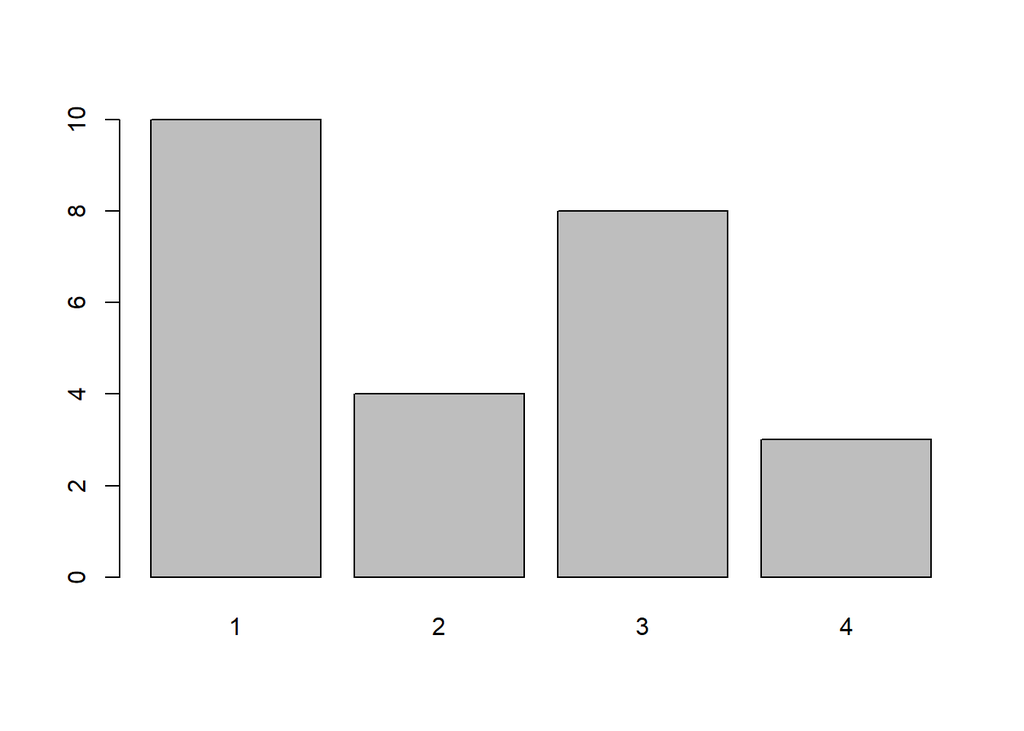

  ```r
  # Beer Preference example
  beer <- c(3, 4, 1, 1, 3, 4, 3, 3, 1, 3, 2, 1, 2,
            1, 2, 3, 2, 3, 1, 1, 1, 1, 4, 3, 1)
  # (1) Domestic can  (2) Domestic bottle,
  # (3) Microbrew     (4) Import

  barplot(table(beer))
  ```

  - `table()` 함수는 도수분포표를 작성
  - 위 그림… 너무 무성의한 도표임. 약간의 화장을 하면…

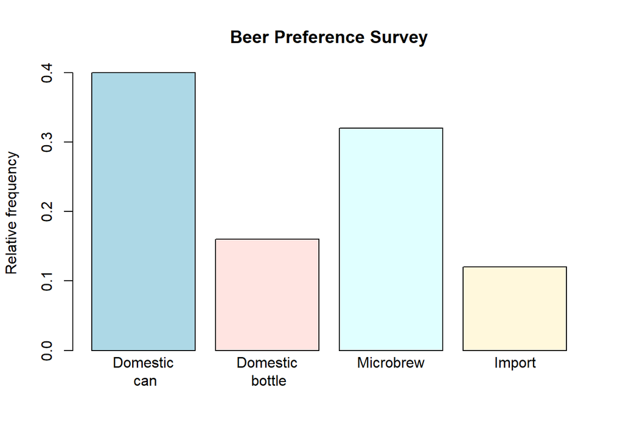

  ```r
  barplot(table(beer)/length(beer),                                   # 상대도수
          col=c("lightblue", "mistyrose", "lightcyan","cornsilk"),    # 막대 색깔
          names.arg=c("Domestic\n can", "Domestic\n bottle", "Microbrew\n", "Import\n"),  # 막대 라벨
          ylab="Relative frequency",
          main="Beer Preference Survey")
  ```

  - `names.arg=` 옵션의 `\\n` 는 줄바꿈을 하라는 의미
- Pie chart: `pie()` 함수 이용

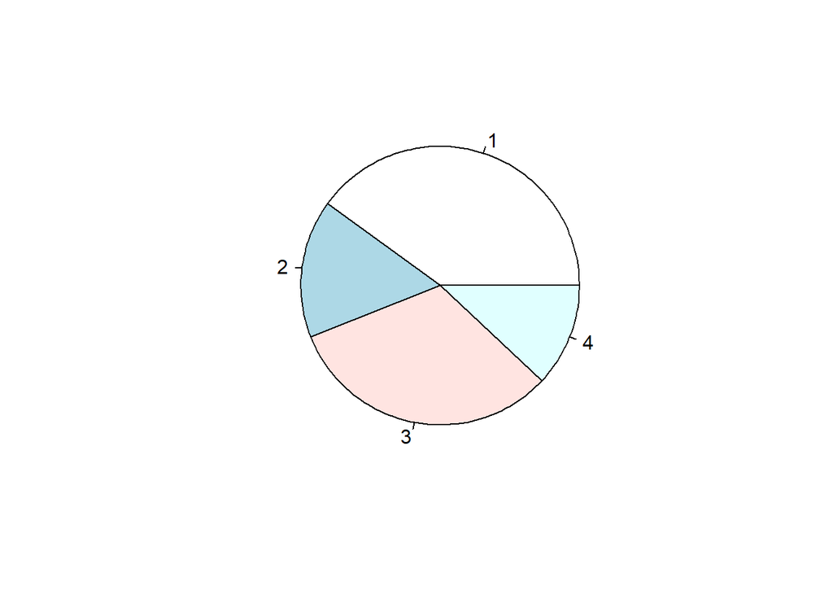

  ```r
  beer.counts <- table(beer) # store the table result
  pie(beer.counts) # first pie -- kind of dull
  ```

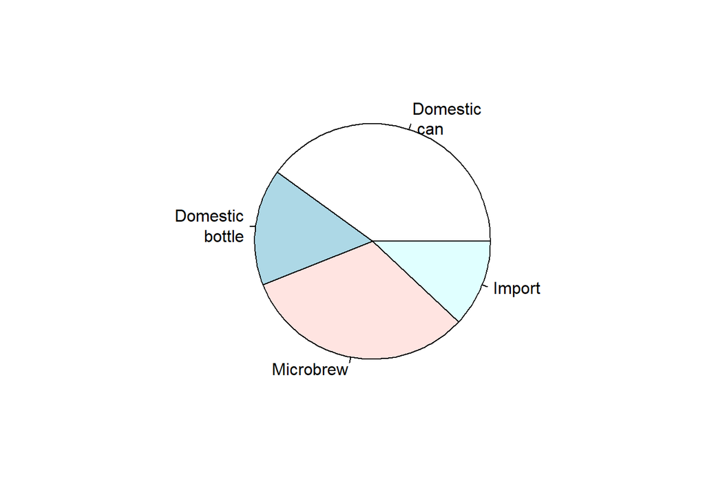

  ```r
  names(beer.counts) <- c("Domestic\n can","Domestic\n bottle", "Microbrew","Import") # give names
  pie(beer.counts) # prints out names
  ```

## D.2 양적 자료(Quantitative data)의 요약

- Stem-and-leaf plot: `stem()` 함수 이용

  ```r
  scores <- c(2, 3, 16, 23, 14, 12, 4, 13, 2, 0, 0, 0, 6, 28, 31, 14, 4, 8, 2, 5)
  stem(scores)
  ```

  ```
  ##
  ##   The decimal point is 1 digit(s) to the right of the |
  ##
  ##   0 | 000222344568
  ##   1 | 23446
  ##   2 | 38
  ##   3 | 1
  ```

- Histogram: `hist()` 함수 이용

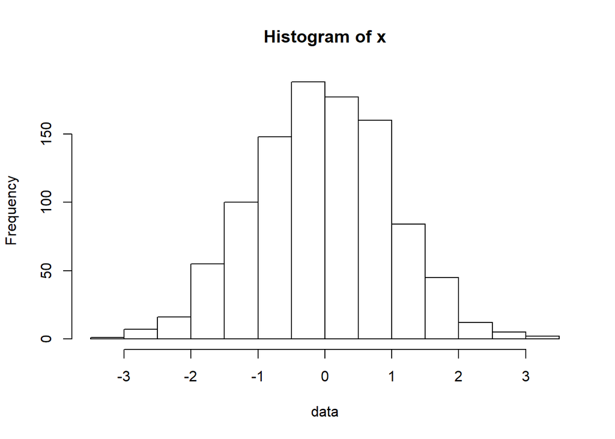

  ```r
  x <- rnorm(1000)  # To generate 1,000 random numbers from N(0,1)
  hist(x, xlab="data")
  ```

  - 대체로 난수의 질이 괜찮아보임. 보다 확실히 알아보기 위해 상대도수히스토그램을 target 분포인 N(0,1)의 밀도함수와 비교

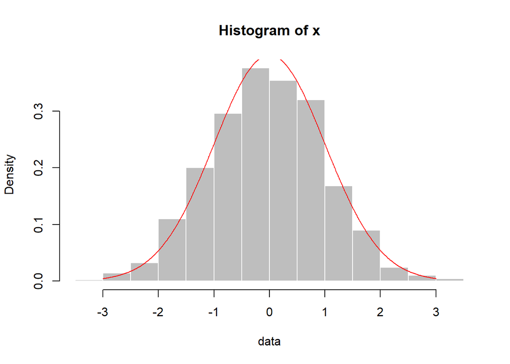

  ```r
  hist(x, probability=T, xlab="data", col="gray", border="white")
  z <- seq(from=-3, to=3, by=0.01)      # N(0,1)의 밀도함수 곡선을 위한 grid 잡기
  lines(z, dnorm(z), col=2)             # 빨간 색으로 N(0,1)의 밀도함수 곡선 덧그리기
  ```

  - `lines()` 함수는 기존의 plot위에 선을 추가하는 함수임
- Boxplot: `boxplot()` 함수 이용

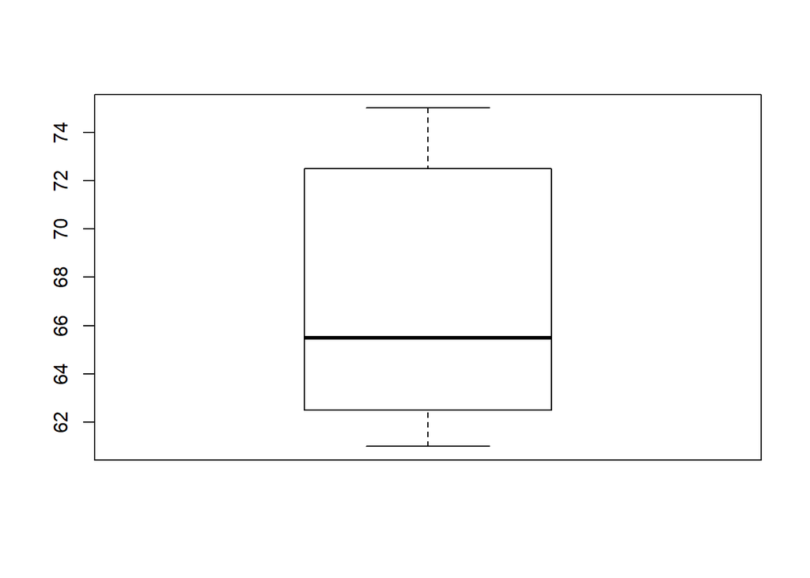

  ```r
  growth <- c(75,72,73,61,67,64,62,63) # the size of flies
  sugar <- c("C","C","C","F","F","F","S","S") # diet
  fly <- data.frame(growth=growth, sugar=sugar)
  boxplot(fly$growth)
  ```

- Scatterplot: `plot()` 함수 이용

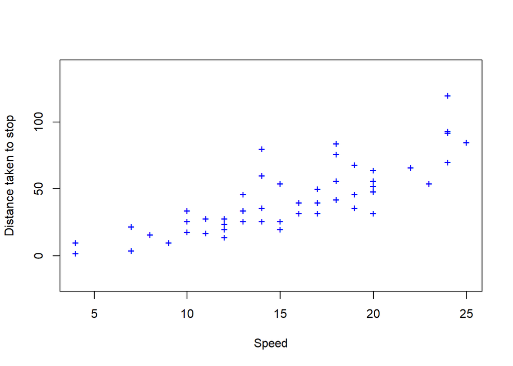

  ```r
  # cars: built-in dataset with the speed of cars and the distances taken to stop
  plot(cars$speed, cars$dist,
       col="blue", pch="+",
       ylab="Distance taken to stop", xlab="Speed",
       ylim=c(-20, 140))
  ```

  - `with()` 함수를 사용하면 변수명에 `cars$`를 사용하지 않아도 되기 때문에 보다 깔끔한 코딩 가능

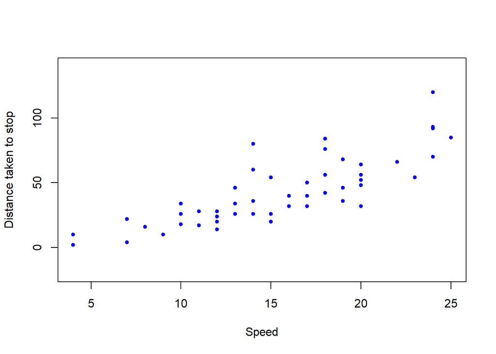

  ```r
  with(cars, plot(speed, dist,
                  col="blue", pch=20,
                  ylab="Distance taken to stop", xlab="Speed",
                  ylim=c(-20, 140)))
  ```

# E. 프로그래밍

> 이 절에서는 반복적인 작업을 단순화하거나 코드를 보다 읽기 좋도록 하기 위해 R 프로그래밍에서 사용하는 제어문들을 익힌다.

## E.1 조건문

- ’if-else’를 사용한 조건문

  ```r
  x <- 10
  if (x < 3) print("x < 3") else print("x >= 3")
  ```

  ```
  ## [1] "x >= 3"
  ```

- `ifelse()` 함수

  ```r
  y <- -3:3
  z <- ifelse(y < 0, -1, 1)
  cbind(y, z)
  ```

  ```
  ##       y  z
  ## [1,] -3 -1
  ## [2,] -2 -1
  ## [3,] -1 -1
  ## [4,]  0  1
  ## [5,]  1  1
  ## [6,]  2  1
  ## [7,]  3  1
  ```

- Commands can be grouped by braces.

  ```r
  x <- 4
  if ( x < 3 ) {
    print("x<3")
    z <- "M"
  } else {
      print("x>3")
      z <- "F"
  }
  ```

  ```
  ## [1] "x>3"
  ```

## E.2 반복문

> 루프(loop)란 반복적으로 실행되는 명령 사이클을 의미한다.  
> R에서 루프를 사용할 때 대표적 방법은 `for` 문을 사용하는 방법과 `while`문을 사용하는 방법이 있다.
- for문: `for(i in 벡터){명령어...}` 와 같은 형태로 사용.  
  벡터 내 모든 성분에 대해 루프를 돌림
  - 아래 코드는 for문을 사용해 1부터 10까지의 합을 계산하고 루프를 돌리는 동안 부분합을 화면에 출력하는 예이다.

  ```r
  n <- 10
  x <- 1:n
  sum.so.far <- 0
  for ( i in 1:n ) {
    sum.so.far <- sum.so.far + x[i]
    print(sum.so.far)
  }
  ```

  ```
  ## [1] 1
  ## [1] 3
  ## [1] 6
  ## [1] 10
  ## [1] 15
  ## [1] 21
  ## [1] 28
  ## [1] 36
  ## [1] 45
  ## [1] 55
  ```

  ```r
  sum.so.far
  ```

  ```
  ## [1] 55
  ```

- while문: `while(조건){명령어...}` 와 같은 형태로 사용.  
  반복 횟수를 미리 알 수 없고 대신 루프를 지속할 수 있는 조건만 줄 수 있을 때 사용
  - 아래 코드는 1부터 시작해 자연수를 누적 합을 구하되 누적 합이 1,000 이내인 동안만 루프를 돌리고 1,000을 초과하면 루프를 중지하는 예임

  ```r
  n <- 0
  sum.so.far <- 0
  while ( sum.so.far <= 1000 ) {
    n <- n+1
    sum.so.far <- sum.so.far + n
  }
  print(c(n, sum.so.far))
  ```

  ```
  ## [1]   45 1035
  ```

  ```r
  sum(1:45)
  ```

  ```
  ## [1] 1035
  ```

- 루프를 강제로 빠져나오게 하려면 `break`문 사용
  - 아래 코드는 1부터 시작해 자연수를 누적 합을 구하되 누적 합이 1,000 이내인 동안만 루프를 돌리는 예임

  ```r
  n <- 0
  sum.so.far <- 0
  while (1) {          # 조건문 자리에 1(TRUE와 동일한 효과)이 있으므로 무한루프
    if(sum.so.far > 1000) break
    n <- n+1
    sum.so.far <- sum.so.far + n
  }
  print(c(n, sum.so.far))
  ```

  ```
  ## [1]   45 1035
  ```

- 가능하면 루프는 사용하지 않는 것이 좋음
  - 벡터 연산 혹은 행렬 연산으로 해결할 수 있는 작업은 루프를 사용하지 않아야 함
  - 계산 시간을 절약하고 코드의 가독성을 향상시키기 위함임
  - 아래 코드는 1부터 100,000,000까지의 자연수로 이루어진 벡터를 다른 이름의 벡터로 복사하는 예임. 시스템 시간을 비교하기 바람.

  ```r
  n <- 100000000
  x <- 1:n
  system.time(y <- x)
  ```

  ```
  ##    user  system elapsed
  ##       0       0       0
  ```

  ```r
  system.time(for (i in 1:n) y[i] <- x[i])
  ```

  ```
  ##    user  system elapsed
  ##    8.84    0.00    8.88
  ```

## E.3 나만의 R함수 만들기

> 함수(function)란 특정한 작업을 해 결과물을 객체로 되돌려주는 코드 덩어리를 의미한다.  
> R의 여러 패키지에서 제공하는 함수를 이용하는 것으로 충분하지 않아서 직접 새로운 함수를 만들어 사용해야 하는 경우를 종종 만나게 된다.
- 함수의 정의 방법: `함수이름 <- function(함수 인자...) {명령어들...}`
  - 아래 코드는 자료의 평균과 표준편차를 계산해 리턴하고 자료의 분포를 요약한 상자그림 및 히스토그램을 작성하는 함수의 예이다.

  ```r
  my.stat <- function(x)
  {
    m <- mean(x)
    s <- sd(x)
    res <- list(m=m, s=s)

    par(mfrow=c(1, 2))
    boxplot(x, main="Boxplot", horizontal=T)
    hist(x, prob=T, col="skyblue", border="white", main="Histrogram", xlab="data")

    return(res)
  }
  ```

  - 함수를 정의하는 `{}` 안쪽에서 정의된 변수의 이름은 함수 정의 내에서만 유효한 로컬 변수임에 유의
    - 위의 예에서 사용한 `m`, `s`, `res` 등은 함수 정의 내에서만 유효한 로컬 변수
  - 위에서 작성한 새로운 함수를 호출해 사용해 보자.

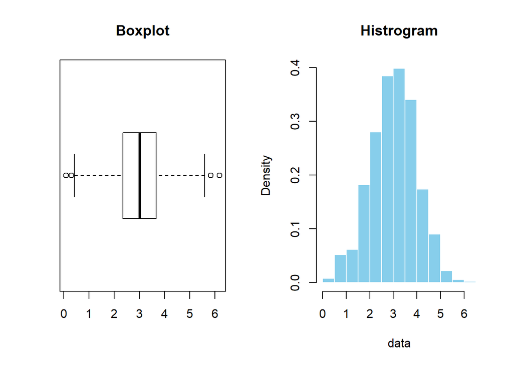

  ```
  ## $m
  ## [1] 3.011606
  ##
  ## $s
  ## [1] 0.9677054
  ```

  ```r
  dat <- rnorm(1000, mean=3, sd=1)
  my.stat(x=dat)
  ```

back to Top